# Final Project

### Boosted Tree Model

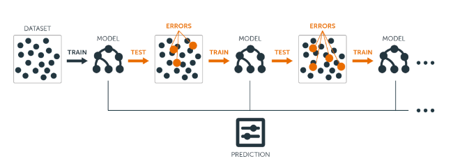

```r
knitr::include_graphics("C:/Users/lisha/Downloads/boost2.png")
```

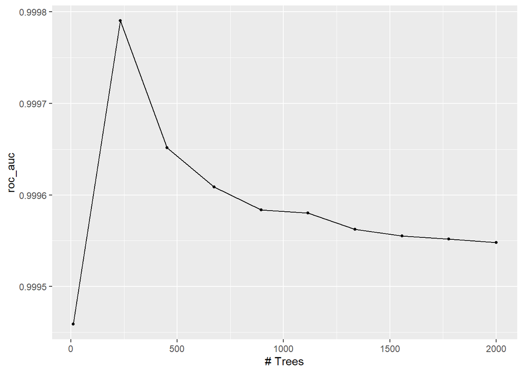

```r
pho_boost_spec<-boost_tree()%>%
  set_engine("xgboost")%>%
  set_mode("classification")
pho_boost_Wkflow<-workflow()%>%
  add_model(pho_boost_spec %>% set_args(trees=tune()))%>%
  add_formula(hazardous~.)
param_grid_boost<-grid_regular(trees(range = c(10,2000)),levels = 10)
tune_res_boost <-tune_grid(
  pho_boost_Wkflow,
  resample=pho_folds,
  grid=param_grid_boost,
  metrics=metric_set(roc_auc)
)
autoplot(tune_res_boost)
```

We achieve the best result when the number of trees is around 200. It seems that when we first increase the tree size, the roc_auc improves significantly. However, when the number of trees exceeds 500, the roc_auc is relatively low. It is worth mentioning that even though we see great improvement from the graph, the difference of best roc_auc and worst is just 0.0003, meaning that our model did very well in all cases.

```r
collect_metrics(tune_res_boost)%>%arrange(-mean)
```

```
## # A tibble: 10 × 7
##    trees .metric .estimator  mean     n  std_err .config
##    <int> <chr>   <chr>      <dbl> <int>    <dbl> <chr>
##  1   231 roc_auc binary     1.00      5 0.000113 Preprocessor1_Model02
##  2   452 roc_auc binary     1.00      5 0.000187 Preprocessor1_Model03
##  3   673 roc_auc binary     1.00      5 0.000202 Preprocessor1_Model04
##  4   894 roc_auc binary     1.00      5 0.000213 Preprocessor1_Model05
##  5  1115 roc_auc binary     1.00      5 0.000213 Preprocessor1_Model06
##  6  1336 roc_auc binary     1.00      5 0.000221 Preprocessor1_Model07
##  7  1557 roc_auc binary     1.00      5 0.000224 Preprocessor1_Model08
##  8  1778 roc_auc binary     1.00      5 0.000226 Preprocessor1_Model09
##  9  2000 roc_auc binary     1.00      5 0.000228 Preprocessor1_Model10
## 10    10 roc_auc binary     0.999     5 0.000407 Preprocessor1_Model01
```

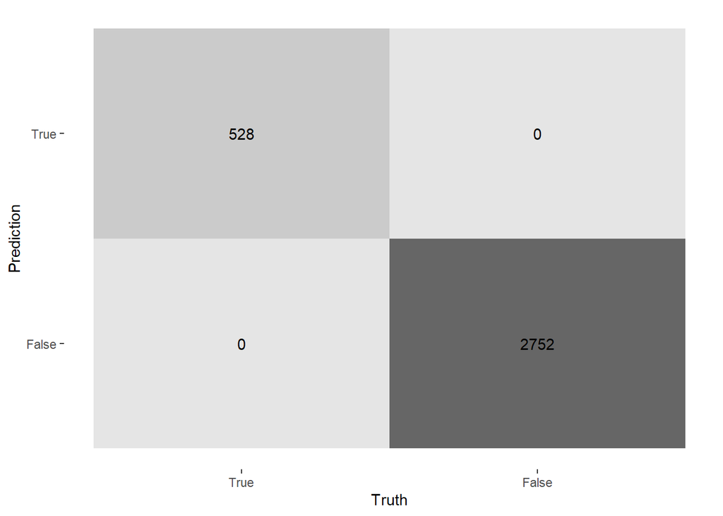

```r
best_tree_boost<-select_best(tune_res_boost)
boost_final<-finalize_workflow(pho_boost_Wkflow,best_tree_boost)
boost_final_fit<-fit(boost_final,data=pho_train)
augment(boost_final_fit,new_data=pho_train) %>%
  conf_mat(truth=hazardous,estimate=.pred_class)%>%
  autoplot(type="heatmap")
```

```r
boost_acc<-augment(boost_final_fit,new_data=pho_train)%>%
  accuracy(truth=hazardous,estimate=.pred_class)
print(boost_acc) # Accuracy is 1
```

```
## # A tibble: 1 × 3
##   .metric  .estimator .estimate
##   <chr>    <chr>          <dbl>
## 1 accuracy binary             1
```

```r
boost_precision<-augment(boost_final_fit,pho_train)%>%
  precision(hazardous,.pred_class) # Precision is 1
print(boost_precision)
```

```
## # A tibble: 1 × 3
##   .metric   .estimator .estimate
##   <chr>     <chr>          <dbl>
## 1 precision binary             1
```

Wow! It is credible that boosted tree even performs better than random forest. **Our accuracy and precision are both 1!** In other words, our boosted tree never misclassfies any observation. I am really amazed by the power of machine learning. I understand that the response variable is unchallenging to predict, but it is not easy to correctly predict more than three thousand observations! I am very curious if this model can have the same accuracy and precision in the testing data.